# moderation, mediation amd moderated mediation

Keon-Woong Moon

2018-09-14

## sample Data(1)

Data `education` is included in semMediation package. This data contains education duration, age, income of teachers, number of students in class.

- age = teachers age
- number = number of students in class
- duration = education duration
- income = income

### mean centering

We perform mean centering of independent and moderating variables.

```r
library(semMediation)
newData=meanCentering(education,colnames(education)[1:3])
str(newData)
```

```
#> 'data.frame':    850 obs. of  7 variables:
#>  $ age       : int  41 27 40 41 24 41 39 43 24 36 ...
#>  $ number    : int  17 10 15 15 2 5 20 12 3 0 ...
#>  $ duration  : int  12 6 14 14 0 5 9 11 4 13 ...
#>  $ income    : int  176 31 55 120 28 25 67 38 19 25 ...
#>  $ age.c     : num [1:850, 1] 5.97 -8.03 4.97 5.97 -11.03 ...
#>   ..- attr(*, "scaled:center")= num 35
#>  $ number.c  : num [1:850, 1] 8.43 1.43 6.43 6.43 -6.57 ...
#>   ..- attr(*, "scaled:center")= num 8.57
#>  $ duration.c: num [1:850, 1] 3.63 -2.37 5.63 5.63 -8.37 ...
#>   ..- attr(*, "scaled:center")= num 8.37
```

### Double moderation

You can make double moderation equation with modmedEquation() function.

```r
moderator=list(name=c("number.c","age.c"),site=c("c","c"))
equation=modmedEquation(X="duration.c",Y="income",moderator=moderator)
cat(equation)
```

```
#> income ~ c1*duration.c+c2*number.c+c3*duration.c:number.c+c4*age.c+c5*duration.c:age.c
#> number.c ~ number.c.mean*1
#> number.c ~~ number.c.var*number.c
#> age.c ~ age.c.mean*1
#> age.c ~~ age.c.var*age.c
```

```r
library(lavaan)
fit=sem(model=equation,data=newData)
estimatesTable2(fit)
```

| Variables | Predictors | B | SE | z | p | β |
| --- | --- | --- | --- | --- | --- | --- |
| income | duration.c | -0.09 | 0.17 | -0.54 | 0.588 | -0.02 |
| income | number.c | 2.66 | 0.15 | 18.11 | < 0.001 | 0.51 |
| income | duration.c:number.c | 0.12 | 0.02 | 5.13 | < 0.001 | 0.17 |
| income | age.c | 1.05 | 0.12 | 8.49 | < 0.001 | 0.24 |
| income | duration.c:age.c | -0.01 | 0.02 | -0.40 | 0.692 | -0.01 |

You can draw conceptual diagram with conceptDiagram().

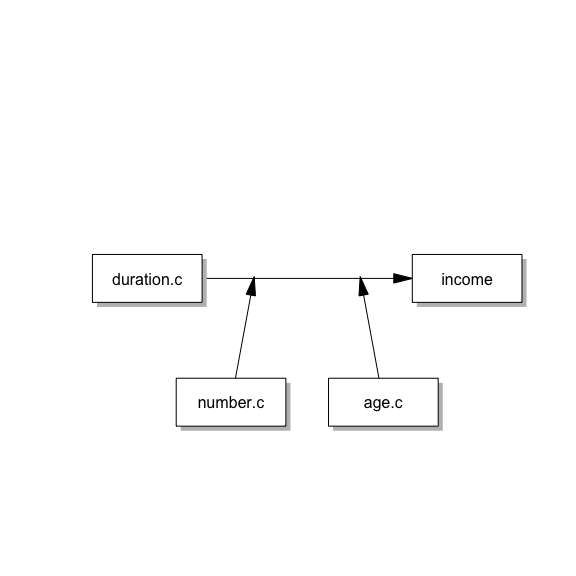

```r
conceptDiagram(fit)
```

You can get path diagram of this moderation model.

```r
semDiagram(fit)
```

[interactive chart not shown]

You can use labels in diagrams.

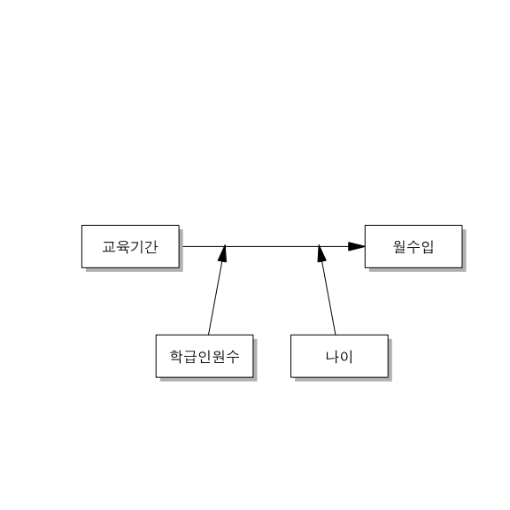

```r
labels <- list(duration.c = "교육기간", number.c = "학급인원수", age.c="나이",
               duration.cnumber.c = "교육기간X학급인원수", duration.cage.c="교육기간X나이",income = "월수입")

if(Sys.info()[["sysname"]] == "Darwin") par(family="AppleGothic")
conceptDiagram(fit,labels=labels)
```

```r
semDiagram(fit,labels=labels)
```

[interactive chart not shown]

## Sample Data(2)

### Describe the dataset

We are going to simulate a dataset that measured the following:

- X = Time spent in graduate school (we will change the name to “time” when we create the data frame)
- Z = Time spent (hours per week) with Professor Demos in class or in office hours
- M = Number of publications in grad school
- Y = Number of job offers

### Create the dataset

We are intentionally creating a moderated mediation effect here and we do so below by setting the relationships (the paths) between our causal chain variables and setting the relationships for our interaction terms. This example is adopted from “A Language, not a Letter: Learning Statistics in R” chapter 15 by Anthony N. Washburn(https://ademos.people.uic.edu/Chapter15.html)

```r
set.seed(42) #This makes sure that everyone gets the same numbers generated through rnorm function
a1 = -.59 #Set the path a1 strength (effect of X on M)
a2 = -.17 #Set path a2 strength (effect of Z on M)
a3 = .29 #Set path a3 strength (interaction between X and Z on M)
b = .59 #Set path b strength (effect of M on Y)
cdash1 = .27 #Set path c'1 strength (effect of X on Y)
cdash2 = .01 #Set path c'2 strength (effect of Z on Y)
cdash3 = -.01 #Set path c'3 strength (interaction betwee X and Z on Y)
```

```r
n <- 200 #Set sample size
X <- rnorm(n, 7, 1) #IV: Time spent in grad school (M = 7, SD = 1)
Z <- rnorm(n, 5, 1) #Moderator: Time spent (hours per week) with Professor Demos in class or in office hours (M = 5, SD = 1)
M <- a1*X + a2*Z + a3*X*Z + rnorm(n, 0, .1) #Mediator: Number of publications in grad school
#The mediator variable is created as a function of the IV, moderator, and their interaction with some random noise thrown in the mix
Y <- cdash1*X + cdash2*Z + cdash3*X*Z + b*M + rnorm(n, 0, .1) #DV: Number of job offers
#Similar to the mediator, the DV is a function of the IV, moderator, their interaction, and the mediator with some random noise thrown in the mix
```

Now we put it all together and make our data frame.

```r
Success <- data.frame(jobs = Y, time = X, pubs = M, alex = Z)
```

```r
Success <- meanCentering(Success,c("time","alex"))
str(Success)
```

```
#> 'data.frame':    200 obs. of  6 variables:
#>  $ jobs  : num  3.17 4.54 6.29 7.53 3.32 ...
#>  $ time  : num  8.37 6.44 7.36 7.63 7.4 ...
#>  $ pubs  : num  1.97 5.16 7.79 9.93 2.74 ...
#>  $ alex  : num  3 5.33 6.17 7.06 3.62 ...
#>  $ time.c: num [1:200, 1] 1.398 -0.537 0.391 0.66 0.432 ...
#>   ..- attr(*, "scaled:center")= num 6.97
#>  $ alex.c: num [1:200, 1] -2.012 0.322 1.16 2.048 -1.388 ...
#>   ..- attr(*, "scaled:center")= num 5.01
```

## Moderation

```r
require(lavaan)
model=modmedEquation(X="time.c",Y="pubs",moderator=list(name="alex.c",site="c"))
cat(model)
```

```
#> pubs ~ c1*time.c+c2*alex.c+c3*time.c:alex.c
#> alex.c ~ alex.c.mean*1
#> alex.c ~~ alex.c.var*alex.c
```

```r
model='pubs~time.c+alex.c+time.c:alex.c'
fit=sem(model,data=Success)
```

You can draw cenceptual diagram using conceptDiagram() function.

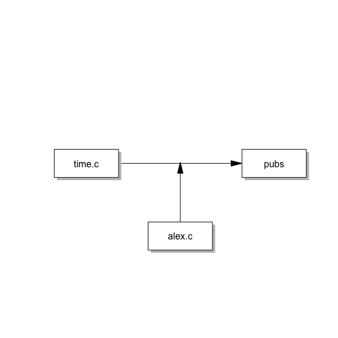

```r
require(semMediation)
conceptDiagram(fit)
```

You can use labels in conceptDiagram() function.

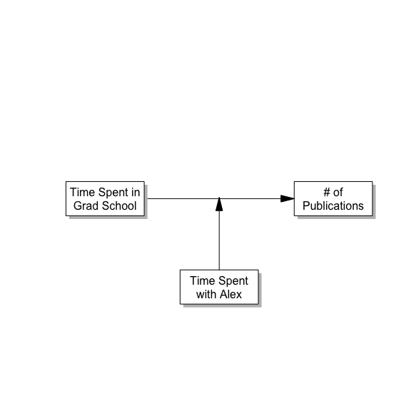

```r
labels=list(time.c="Time Spent in\nGrad School",
            alex.c="Time Spent\nwith Alex",
            pubs="# of\nPublications")
conceptDiagram(fit,labels=labels)
```

You can get path diagram of this moderation model.

```r
semDiagram(fit)
```

[interactive chart not shown]

```r
semDiagram(fit,labels=labels)
```

[interactive chart not shown]

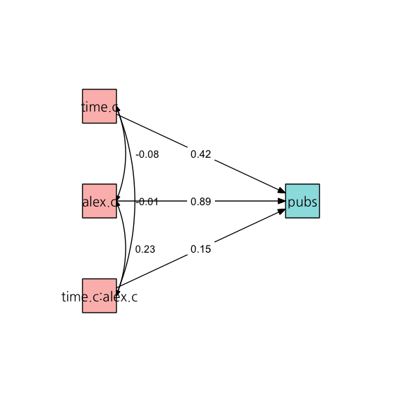

```r
mediationPlot(fit)
```

## Mediation Model

You can make mediation model with this data.

```r
model=makeEquation(X="time.c",M="pubs",Y="jobs")
cat(model)
```

```
#> # Mediation Effect
#> jobs~b1*pubs+c1*time.c
#> pubs~a1*time.c
#> ind1:=a1*b1
#> total1:=c1+a1*b1
```

```r
fit=sem(model,data=Success)
```

You can draw conceptual model with conceptDiagram() function.

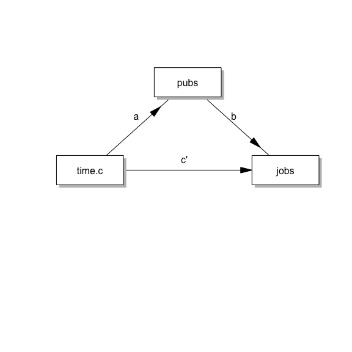

```r
conceptDiagram(fit)
```

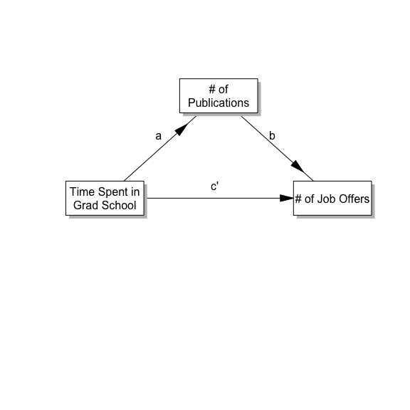

```r
labels=list(time.c="Time Spent in\nGrad School",
            pubs="# of\nPublications",
            jobs="# of Job Offers"
            )
conceptDiagram(fit,labels=labels)
```

You can get path diagram of this mediation model.

```r
semDiagram(fit)
```

[interactive chart not shown]

```r
semDiagram(fit,labels=labels)
```

[interactive chart not shown]

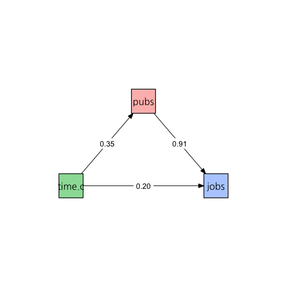

```r
mediationPlot(fit)
```

## Moderated Mediation Model(1)

```r
X="time.c";M="pubs";Y="jobs"
moderator=list(name=c("time.c"),site=list(c("b")))
model=modmedEquation(X=X,M=M,Y=Y,moderator=moderator)
cat(model)
```

```
#> pubs ~ a1*time.c
#> jobs ~ c1*time.c + b1*pubs+b2*pubs:time.c
#> time.c ~ time.c.mean*1
#> time.c ~~ time.c.var*time.c
#> indirect :=(a1)*(b1+b2*time.c.mean)
#> direct :=c1
#> total := direct + indirect
```

```r
fit=sem(model,data=Success)
estimatesTable2(fit)
```

| Variables | Predictors | B | SE | z | p | β |
| --- | --- | --- | --- | --- | --- | --- |
| pubs | time.c | 0.71 | 0.13 | 5.31 | < 0.001 | 0.35 |
| jobs | time.c | 0.24 | 0.01 | 34.05 | < 0.001 | 0.20 |
| jobs | pubs | 0.56 | 0.00 | 156.90 | < 0.001 | 0.91 |
| jobs | pubs:time.c | -0.00 | 0.00 | -0.55 | 0.583 | -0.00 |

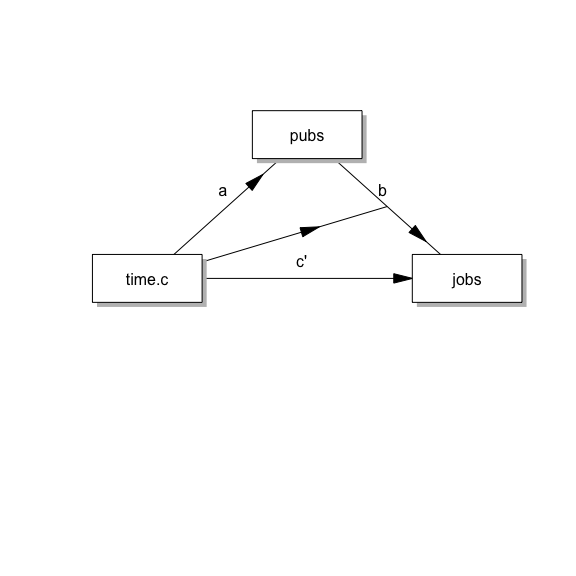

```r
conceptDiagram(fit)
```

```r
semDiagram(fit)
```

[interactive chart not shown]

## Moderated Mediation Model(2)

```r
X="time.c";M="pubs";Y="jobs"
moderator=list(name=c("alex.c"),site=list(c("a","c")))
model=modmedEquation(X=X,M=M,Y=Y,moderator=moderator,range=TRUE)
cat(model)
```

```
#> pubs ~ a1*time.c+a2*alex.c+a3*time.c:alex.c
#> jobs ~ c1*time.c+c2*alex.c+c3*time.c:alex.c + b1*pubs
#> alex.c ~ alex.c.mean*1
#> alex.c ~~ alex.c.var*alex.c
#> indirect :=(a1+a3*alex.c.mean)*(b1)
#> direct :=c1+c3*alex.c.mean
#> total := direct + indirect
#> indirect.SDbelow :=(a1+a3*(alex.c.mean-sqrt(alex.c.var)))*(b1)
#> indirect.SDabove :=(a1+a3*(alex.c.mean+sqrt(alex.c.var)))*(b1)
#> direct.SDbelow:=c1+c3*(alex.c.mean-sqrt(alex.c.var))
#> direct.SDabove:=c1+c3*(alex.c.mean+sqrt(alex.c.var))
#> total.SDbelow := direct.SDbelow + indirect.SDbelow
#> total.SDabove := direct.SDabove + indirect.SDabove
#> prop.mediated.SDbelow := indirect.SDbelow / total.SDbelow
#> prop.mediated.SDabove := indirect.SDabove / total.SDabove
#> index.mod.med := a3*b1
```

```r
fit=sem(model,data=Success)
estimatesTable2(fit)
```

| Variables | Predictors | B | SE | z | p | β |
| --- | --- | --- | --- | --- | --- | --- |
| pubs | time.c | 0.86 | 0.01 | 115.65 | < 0.001 | 0.42 |
| pubs | alex.c | 1.85 | 0.01 | 242.92 | < 0.001 | 0.89 |
| pubs | time.c:alex.c | 0.31 | 0.01 | 40.43 | < 0.001 | 0.15 |
| jobs | time.c | 0.22 | 0.06 | 3.96 | < 0.001 | 0.18 |
| jobs | alex.c | -0.05 | 0.12 | -0.40 | 0.686 | -0.04 |
| jobs | time.c:alex.c | -0.01 | 0.02 | -0.45 | 0.653 | -0.01 |
| jobs | pubs | 0.58 | 0.06 | 9.11 | < 0.001 | 0.94 |

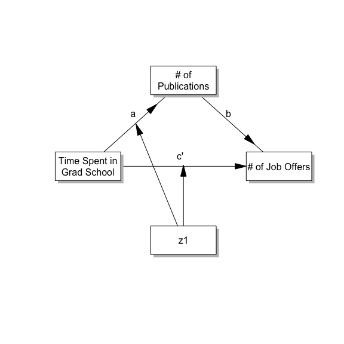

```r
conceptDiagram(fit,labels=labels)
```

```r
semDiagram(fit,labels=labels)
```

[interactive chart not shown]

## Moderated Mediation Model(2)

```r
X="time.c";M="pubs";Y="jobs"
moderator=list(name=c("alex.c"),site=list(c("a","b")))
model=modmedEquation(X=X,M=M,Y=Y,moderator=moderator)
cat(model)
```

```
#> pubs ~ a1*time.c+a2*alex.c+a3*time.c:alex.c
#> jobs ~ c1*time.c + b1*pubs+b2*alex.c+b3*pubs:alex.c
#> alex.c ~ alex.c.mean*1
#> alex.c ~~ alex.c.var*alex.c
#> indirect :=(a1+a3*alex.c.mean)*(b1+b3*alex.c.mean)
#> direct :=c1
#> total := direct + indirect
```

```r
fit=sem(model,data=Success)
estimatesTable2(fit)
```

| Variables | Predictors | B | SE | z | p | β |
| --- | --- | --- | --- | --- | --- | --- |
| pubs | time.c | 0.86 | 0.01 | 115.65 | < 0.001 | 0.42 |
| pubs | alex.c | 1.85 | 0.01 | 242.92 | < 0.001 | 0.89 |
| pubs | time.c:alex.c | 0.31 | 0.01 | 40.43 | < 0.001 | 0.15 |
| jobs | time.c | 0.24 | 0.02 | 12.21 | < 0.001 | 0.19 |
| jobs | pubs | 0.56 | 0.02 | 25.66 | < 0.001 | 0.89 |
| jobs | alex.c | 0.01 | 0.04 | 0.32 | 0.745 | 0.01 |
| jobs | pubs:alex.c | -0.00 | 0.00 | -2.92 | 0.003 | -0.02 |

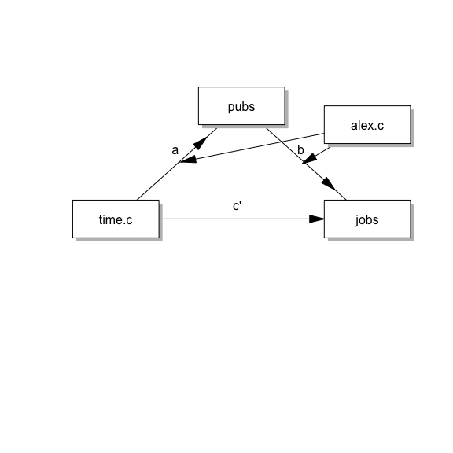

```r
conceptDiagram(fit)
```

```r
semDiagram(fit)
```

[interactive chart not shown]